# Lista de Artículos

Aquí encontraras todos los artículos relacionados con estadística y ciencia de datos que se han publicado en este blog hasta la fecha.

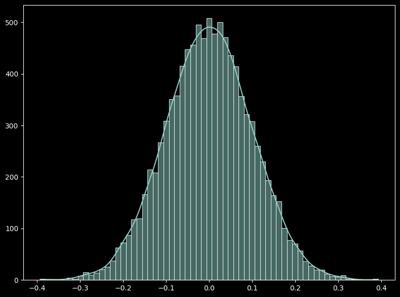

### Conceptos Básicos de las Pruebas de Hipótesis

Explora los fundamentos de las pruebas de hipótesis en estadística, la formulación de hipótesis nula y alternativa hasta la comprensión de la significancia estadística y los errores de tipo I y II… Leer más

[figure not shown]

### Fundamentos de las Distribuciones de Probabilidad

Cubre variables aleatorias, espacios muestrales, distribuciones discretas y continuas, y distribuciones de probabilidad multivariadas. El artículo destaca las condiciones clave para cada tipo de distribución y su aplicación en el análisis estadístico… Leer más

[figure not shown]

### La Distribución Normal o Gaussiana

En este artículo, exploramos la distribución normal, desde su función de distribución acumulada (CDF) hasta la función de punto de probabilidad (PPF). Además, examinamos el teorema central del límite (TCL), revelando su amplio impacto en diversos campos. Este análisis resalta la omnipresencia y la importancia de la distribución normal en estadística y probabilidad… Leer más

[figure not shown]

### Tipos de Pruebas de Hipótesis:

En este artículo, hablo sobre los métodos para realizar pruebas de hipótesis relativas a la media poblacional para datos que siguen una distribución normal. Los tres métodos más comunes son: valores críticos, el valor $p$, los intervalos de confianza y su versión normalizada…. Leer más

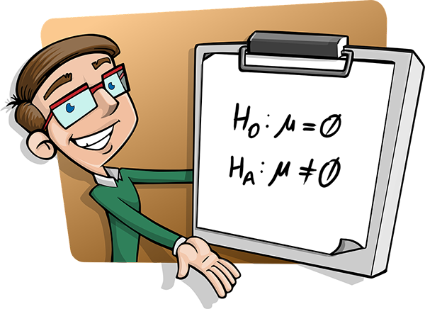

### Otros Conceptos de las Pruebas de Hipótesis I:

En este artículo complementario, explico otras formas de formular las hipótesis, la unidad tipificada o valores $z$, y cómo y en qué condiciones se puede calcular la probabilidad de los errores de tipo I y II en dichas pruebas…. Leer más

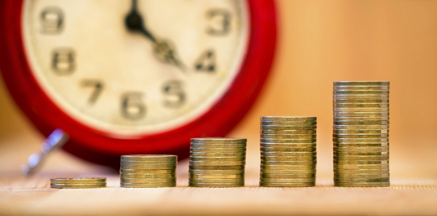

### Introducción a las Matemáticas Financieras:

El artículo explica la importancia de las matemáticas financieras en la asignación de recursos, se centra en el valor del dinero en el tiempo. Introduce el concepto de interés y sus causas, incluyendo la inflación, el costo de oportunidad y la preferencia temporal, y presenta la tasa de interés y su cálculo….. Leer más